# Personal Loan Campaing

## Introduction

AllLife US Bank has loan department that is looking to grow their customer base. The majority of these customers are liability customers (depositors) with varying sizes of deposits. Borrowers (asset customers) is quite small. AllLife US Bank is looking to expand asset customers to bring in more loan business and earn more through interest on loans. Management is interested in more ways of converting liability customers to personal loan customers (while retaining them as depositors).

## Objective

As Data Scientists for AllLife Bank we will build an accurate model to help the marketing department, identify potential customers (new and current customers) who have higher probability of purchasing a loan.

## Key Questions

1. To predict whether a liability customer will buy a personal loan or not.
2. Which variables are most significant.
3. Which segment of customers should be targeted more.

## Data Dictionary

- ID: Customer ID
- Age: Customer’s age in completed years
- Experience: #years of professional experience
- Income: Annual income of the customer (in thousand dollars)
- ZIP Code: Home Address ZIP code.
- Family: the Family size of the customer
- CCAvg: Average spending on credit cards per month (in thousand dollars)
- Education: Education Level. 1: Undergrad; 2: Graduate;3: Advanced/Professional
- Mortgage: Value of house mortgage if any. (in thousand dollars)
- Personal_Loan: Did this customer accept the personal loan offered in the last campaign?
- Securities_Account: Does the customer have securities account with the bank?
- CD_Account: Does the customer have a certificate of deposit (CD) account with the bank?
- Online: Do customers use internet banking facilities?
- CreditCard: Does the customer use a credit card issued by any other Bank (excluding All life Bank)?

```python
import pandas as pd
import numpy as np
from sklearn import metrics
import matplotlib.pyplot as plt
%matplotlib inline
import seaborn as sns
from sklearn.model_selection import train_test_split
from sklearn.tree import DecisionTreeClassifier
from sklearn import tree
from statsmodels.stats.outliers_influence import variance_inflation_factor
from sklearn.model_selection import GridSearchCV

import warnings
warnings.filterwarnings("ignore")
```

```python
df = "Loan_Modelling.csv"
df = pd.read_csv(df)

df.head(20)
```

|  | ID | Age | Experience | Income | ZIPCode | Family | CCAvg | Education | Mortgage | Personal_Loan | Securities_Account | CD_Account | Online | CreditCard |
| --- | --- | --- | --- | --- | --- | --- | --- | --- | --- | --- | --- | --- | --- | --- |
| 0 | 1 | 25 | 1 | 49 | 91107 | 4 | 1.6 | 1 | 0 | 0 | 1 | 0 | 0 | 0 |
| 1 | 2 | 45 | 19 | 34 | 90089 | 3 | 1.5 | 1 | 0 | 0 | 1 | 0 | 0 | 0 |
| 2 | 3 | 39 | 15 | 11 | 94720 | 1 | 1.0 | 1 | 0 | 0 | 0 | 0 | 0 | 0 |
| 3 | 4 | 35 | 9 | 100 | 94112 | 1 | 2.7 | 2 | 0 | 0 | 0 | 0 | 0 | 0 |
| 4 | 5 | 35 | 8 | 45 | 91330 | 4 | 1.0 | 2 | 0 | 0 | 0 | 0 | 0 | 1 |
| 5 | 6 | 37 | 13 | 29 | 92121 | 4 | 0.4 | 2 | 155 | 0 | 0 | 0 | 1 | 0 |
| 6 | 7 | 53 | 27 | 72 | 91711 | 2 | 1.5 | 2 | 0 | 0 | 0 | 0 | 1 | 0 |
| 7 | 8 | 50 | 24 | 22 | 93943 | 1 | 0.3 | 3 | 0 | 0 | 0 | 0 | 0 | 1 |
| 8 | 9 | 35 | 10 | 81 | 90089 | 3 | 0.6 | 2 | 104 | 0 | 0 | 0 | 1 | 0 |
| 9 | 10 | 34 | 9 | 180 | 93023 | 1 | 8.9 | 3 | 0 | 1 | 0 | 0 | 0 | 0 |
| 10 | 11 | 65 | 39 | 105 | 94710 | 4 | 2.4 | 3 | 0 | 0 | 0 | 0 | 0 | 0 |
| 11 | 12 | 29 | 5 | 45 | 90277 | 3 | 0.1 | 2 | 0 | 0 | 0 | 0 | 1 | 0 |
| 12 | 13 | 48 | 23 | 114 | 93106 | 2 | 3.8 | 3 | 0 | 0 | 1 | 0 | 0 | 0 |
| 13 | 14 | 59 | 32 | 40 | 94920 | 4 | 2.5 | 2 | 0 | 0 | 0 | 0 | 1 | 0 |
| 14 | 15 | 67 | 41 | 112 | 91741 | 1 | 2.0 | 1 | 0 | 0 | 1 | 0 | 0 | 0 |
| 15 | 16 | 60 | 30 | 22 | 95054 | 1 | 1.5 | 3 | 0 | 0 | 0 | 0 | 1 | 1 |
| 16 | 17 | 38 | 14 | 130 | 95010 | 4 | 4.7 | 3 | 134 | 1 | 0 | 0 | 0 | 0 |
| 17 | 18 | 42 | 18 | 81 | 94305 | 4 | 2.4 | 1 | 0 | 0 | 0 | 0 | 0 | 0 |
| 18 | 19 | 46 | 21 | 193 | 91604 | 2 | 8.1 | 3 | 0 | 1 | 0 | 0 | 0 | 0 |
| 19 | 20 | 55 | 28 | 21 | 94720 | 1 | 0.5 | 2 | 0 | 0 | 1 | 0 | 0 | 1 |

```python
copy_df = df
copy_df.head()
```

|  | ID | Age | Experience | Income | ZIPCode | Family | CCAvg | Education | Mortgage | Personal_Loan | Securities_Account | CD_Account | Online | CreditCard |
| --- | --- | --- | --- | --- | --- | --- | --- | --- | --- | --- | --- | --- | --- | --- |
| 0 | 1 | 25 | 1 | 49 | 91107 | 4 | 1.6 | 1 | 0 | 0 | 1 | 0 | 0 | 0 |
| 1 | 2 | 45 | 19 | 34 | 90089 | 3 | 1.5 | 1 | 0 | 0 | 1 | 0 | 0 | 0 |
| 2 | 3 | 39 | 15 | 11 | 94720 | 1 | 1.0 | 1 | 0 | 0 | 0 | 0 | 0 | 0 |
| 3 | 4 | 35 | 9 | 100 | 94112 | 1 | 2.7 | 2 | 0 | 0 | 0 | 0 | 0 | 0 |
| 4 | 5 | 35 | 8 | 45 | 91330 | 4 | 1.0 | 2 | 0 | 0 | 0 | 0 | 0 | 1 |

```python
copy_df.shape
```

```
(5000, 14)
```

##### Observations

- Dataframe is 5000 rows and 14 columns

```python
copy_df['Personal_Loan'].value_counts()
```

```
0    4520
1     480
Name: Personal_Loan, dtype: int64
```

##### Observations

- 4,520 customers did not accept a personal loan in the last campaign
- 480 customers accepted a personal loan in the last campaign

```python
copy_df.describe().T
```

|  | count | mean | std | min | 25% | 50% | 75% | max |
| --- | --- | --- | --- | --- | --- | --- | --- | --- |
| ID | 5000.0 | 2500.500000 | 1443.520003 | 1.0 | 1250.75 | 2500.5 | 3750.25 | 5000.0 |
| Age | 5000.0 | 45.338400 | 11.463166 | 23.0 | 35.00 | 45.0 | 55.00 | 67.0 |
| Experience | 5000.0 | 20.104600 | 11.467954 | -3.0 | 10.00 | 20.0 | 30.00 | 43.0 |
| Income | 5000.0 | 73.774200 | 46.033729 | 8.0 | 39.00 | 64.0 | 98.00 | 224.0 |
| ZIPCode | 5000.0 | 93169.257000 | 1759.455086 | 90005.0 | 91911.00 | 93437.0 | 94608.00 | 96651.0 |
| Family | 5000.0 | 2.396400 | 1.147663 | 1.0 | 1.00 | 2.0 | 3.00 | 4.0 |
| CCAvg | 5000.0 | 1.937938 | 1.747659 | 0.0 | 0.70 | 1.5 | 2.50 | 10.0 |
| Education | 5000.0 | 1.881000 | 0.839869 | 1.0 | 1.00 | 2.0 | 3.00 | 3.0 |
| Mortgage | 5000.0 | 56.498800 | 101.713802 | 0.0 | 0.00 | 0.0 | 101.00 | 635.0 |
| Personal_Loan | 5000.0 | 0.096000 | 0.294621 | 0.0 | 0.00 | 0.0 | 0.00 | 1.0 |
| Securities_Account | 5000.0 | 0.104400 | 0.305809 | 0.0 | 0.00 | 0.0 | 0.00 | 1.0 |
| CD_Account | 5000.0 | 0.060400 | 0.238250 | 0.0 | 0.00 | 0.0 | 0.00 | 1.0 |
| Online | 5000.0 | 0.596800 | 0.490589 | 0.0 | 0.00 | 1.0 | 1.00 | 1.0 |
| CreditCard | 5000.0 | 0.294000 | 0.455637 | 0.0 | 0.00 | 0.0 | 1.00 | 1.0 |

```python
copy_df.info()
```

```
<class 'pandas.core.frame.DataFrame'>
RangeIndex: 5000 entries, 0 to 4999
Data columns (total 14 columns):
 #   Column              Non-Null Count  Dtype
---  ------              --------------  -----
 0   ID                  5000 non-null   int64
 1   Age                 5000 non-null   int64
 2   Experience          5000 non-null   int64
 3   Income              5000 non-null   int64
 4   ZIPCode             5000 non-null   int64
 5   Family              5000 non-null   int64
 6   CCAvg               5000 non-null   float64
 7   Education           5000 non-null   int64
 8   Mortgage            5000 non-null   int64
 9   Personal_Loan       5000 non-null   int64
 10  Securities_Account  5000 non-null   int64
 11  CD_Account          5000 non-null   int64
 12  Online              5000 non-null   int64
 13  CreditCard          5000 non-null   int64
dtypes: float64(1), int64(13)
memory usage: 547.0 KB
```

```python
copy_df.isnull().sum()
```

```
ID                    0
Age                   0
Experience            0
Income                0
ZIPCode               0
Family                0
CCAvg                 0
Education             0
Mortgage              0
Personal_Loan         0
Securities_Account    0
CD_Account            0
Online                0
CreditCard            0
dtype: int64
```

```python
X=copy_df.drop(["Personal_Loan"], axis=1)
vif = pd.DataFrame()
vif["Variables"] = X.columns
vif["vif_Factor"] = [variance_inflation_factor(X.values, i) for i in range(X.shape[1])]
print(vif)
```

```
             Variables   vif_Factor
0                   ID     4.006100
1                  Age  1352.145932
2           Experience   332.922021
3               Income     6.598811
4              ZIPCode   392.170808
5               Family     5.547455
6                CCAvg     3.854866
7            Education     6.703232
8             Mortgage     1.375942
9   Securities_Account     1.269908
10          CD_Account     1.415094
11              Online     2.579956
12          CreditCard     1.570177
```

##### Observations

- Average age for customers is 45 years old
- Average years of work experience is 20 years for customers
- Average income for customers is 73.77K
- Average credit card spending for customers per month is 1.93K
- Average mortgage amount for customers is 56.49K
- There are no categorical variables
- There are no missing values

```python
# checking for unique values in ID column
copy_df["ID"].nunique()
```

```
5000
```

```python
# checking for unique values in ID column
copy_df["ZIPCode"].nunique()
```

```
467
```

```python
from uszipcode import SearchEngine
search = SearchEngine()

city = []
for i in np.arange(0, len(copy_df['ZIPCode'])):
    zipcode = search.by_zipcode(copy_df['ZIPCode'][i])
    city.append(zipcode.major_city)
```

```python
copy_df['City'] = city
copy_df.head()
```

|  | ID | Age | Experience | Income | ZIPCode | Family | CCAvg | Education | Mortgage | Personal_Loan | Securities_Account | CD_Account | Online | CreditCard | City |
| --- | --- | --- | --- | --- | --- | --- | --- | --- | --- | --- | --- | --- | --- | --- | --- |
| 0 | 1 | 25 | 1 | 49 | 91107 | 4 | 1.6 | 1 | 0 | 0 | 1 | 0 | 0 | 0 | Pasadena |
| 1 | 2 | 45 | 19 | 34 | 90089 | 3 | 1.5 | 1 | 0 | 0 | 1 | 0 | 0 | 0 | Los Angeles |
| 2 | 3 | 39 | 15 | 11 | 94720 | 1 | 1.0 | 1 | 0 | 0 | 0 | 0 | 0 | 0 | Berkeley |
| 3 | 4 | 35 | 9 | 100 | 94112 | 1 | 2.7 | 2 | 0 | 0 | 0 | 0 | 0 | 0 | San Francisco |
| 4 | 5 | 35 | 8 | 45 | 91330 | 4 | 1.0 | 2 | 0 | 0 | 0 | 0 | 0 | 1 | Northridge |

```python
copy_df.info()
```

```
<class 'pandas.core.frame.DataFrame'>
RangeIndex: 5000 entries, 0 to 4999
Data columns (total 15 columns):
 #   Column              Non-Null Count  Dtype
---  ------              --------------  -----
 0   ID                  5000 non-null   int64
 1   Age                 5000 non-null   int64
 2   Experience          5000 non-null   int64
 3   Income              5000 non-null   int64
 4   ZIPCode             5000 non-null   int64
 5   Family              5000 non-null   int64
 6   CCAvg               5000 non-null   float64
 7   Education           5000 non-null   int64
 8   Mortgage            5000 non-null   int64
 9   Personal_Loan       5000 non-null   int64
 10  Securities_Account  5000 non-null   int64
 11  CD_Account          5000 non-null   int64
 12  Online              5000 non-null   int64
 13  CreditCard          5000 non-null   int64
 14  City                4966 non-null   object
dtypes: float64(1), int64(13), object(1)
memory usage: 586.1+ KB
```

```python
print(copy_df.City.value_counts())
```

```
Los Angeles      375
San Diego        269
San Francisco    257
Berkeley         241
Sacramento       148
                ...
Tahoe City         1
Ladera Ranch       1
Stinson Beach      1
Sierra Madre       1
Sausalito          1
Name: City, Length: 244, dtype: int64
```

```python
copy_df["City"].nunique()
```

```
244
```

```python
copy_df.to_csv('Loan_Modelling(copy).csv')
```

```python
copy_df.isnull().sum().sort_values(ascending=False)
```

```
City                  34
CreditCard             0
Online                 0
CD_Account             0
Securities_Account     0
Personal_Loan          0
Mortgage               0
Education              0
CCAvg                  0
Family                 0
ZIPCode                0
Income                 0
Experience             0
Age                    0
ID                     0
dtype: int64
```

```python
copy_df.head(700)
```

|  | ID | Age | Experience | Income | ZIPCode | Family | CCAvg | Education | Mortgage | Personal_Loan | Securities_Account | CD_Account | Online | CreditCard | City |
| --- | --- | --- | --- | --- | --- | --- | --- | --- | --- | --- | --- | --- | --- | --- | --- |
| 0 | 1 | 25 | 1 | 49 | 91107 | 4 | 1.6 | 1 | 0 | 0 | 1 | 0 | 0 | 0 | Pasadena |
| 1 | 2 | 45 | 19 | 34 | 90089 | 3 | 1.5 | 1 | 0 | 0 | 1 | 0 | 0 | 0 | Los Angeles |
| 2 | 3 | 39 | 15 | 11 | 94720 | 1 | 1.0 | 1 | 0 | 0 | 0 | 0 | 0 | 0 | Berkeley |
| 3 | 4 | 35 | 9 | 100 | 94112 | 1 | 2.7 | 2 | 0 | 0 | 0 | 0 | 0 | 0 | San Francisco |
| 4 | 5 | 35 | 8 | 45 | 91330 | 4 | 1.0 | 2 | 0 | 0 | 0 | 0 | 0 | 1 | Northridge |
| ... | ... | ... | ... | ... | ... | ... | ... | ... | ... | ... | ... | ... | ... | ... | ... |
| 695 | 696 | 29 | 4 | 115 | 92717 | 1 | 1.9 | 1 | 0 | 0 | 0 | 0 | 0 | 0 | None |
| 696 | 697 | 51 | 27 | 63 | 92251 | 2 | 1.0 | 3 | 82 | 0 | 0 | 0 | 1 | 0 | Imperial |
| 697 | 698 | 42 | 17 | 85 | 92648 | 1 | 3.7 | 3 | 0 | 0 | 0 | 0 | 1 | 0 | Huntington Beach |
| 698 | 699 | 64 | 38 | 59 | 92028 | 1 | 2.5 | 3 | 220 | 0 | 0 | 0 | 0 | 0 | Fallbrook |
| 699 | 700 | 44 | 20 | 68 | 95060 | 1 | 0.8 | 3 | 91 | 0 | 0 | 0 | 0 | 0 | Santa Cruz |

700 rows × 15 columns

```python
copy_df['City'] = copy_df.City.str.replace('None', '')
```

```python
copy_df = copy_df.fillna("")
copy_df = copy_df.replace(r'^\s*$', np.NaN, regex=True)
copy_df.head(700)
```

|  | ID | Age | Experience | Income | ZIPCode | Family | CCAvg | Education | Mortgage | Personal_Loan | Securities_Account | CD_Account | Online | CreditCard | City |
| --- | --- | --- | --- | --- | --- | --- | --- | --- | --- | --- | --- | --- | --- | --- | --- |
| 0 | 1 | 25 | 1 | 49 | 91107 | 4 | 1.6 | 1 | 0 | 0 | 1 | 0 | 0 | 0 | Pasadena |
| 1 | 2 | 45 | 19 | 34 | 90089 | 3 | 1.5 | 1 | 0 | 0 | 1 | 0 | 0 | 0 | Los Angeles |
| 2 | 3 | 39 | 15 | 11 | 94720 | 1 | 1.0 | 1 | 0 | 0 | 0 | 0 | 0 | 0 | Berkeley |
| 3 | 4 | 35 | 9 | 100 | 94112 | 1 | 2.7 | 2 | 0 | 0 | 0 | 0 | 0 | 0 | San Francisco |
| 4 | 5 | 35 | 8 | 45 | 91330 | 4 | 1.0 | 2 | 0 | 0 | 0 | 0 | 0 | 1 | Northridge |
| ... | ... | ... | ... | ... | ... | ... | ... | ... | ... | ... | ... | ... | ... | ... | ... |
| 695 | 696 | 29 | 4 | 115 | 92717 | 1 | 1.9 | 1 | 0 | 0 | 0 | 0 | 0 | 0 | NaN |
| 696 | 697 | 51 | 27 | 63 | 92251 | 2 | 1.0 | 3 | 82 | 0 | 0 | 0 | 1 | 0 | Imperial |
| 697 | 698 | 42 | 17 | 85 | 92648 | 1 | 3.7 | 3 | 0 | 0 | 0 | 0 | 1 | 0 | Huntington Beach |
| 698 | 699 | 64 | 38 | 59 | 92028 | 1 | 2.5 | 3 | 220 | 0 | 0 | 0 | 0 | 0 | Fallbrook |
| 699 | 700 | 44 | 20 | 68 | 95060 | 1 | 0.8 | 3 | 91 | 0 | 0 | 0 | 0 | 0 | Santa Cruz |

700 rows × 15 columns

```python
copy_df = copy_df.dropna()
```

```python
copy_df.head(700)
```

|  | ID | Age | Experience | Income | ZIPCode | Family | CCAvg | Education | Mortgage | Personal_Loan | Securities_Account | CD_Account | Online | CreditCard | City |
| --- | --- | --- | --- | --- | --- | --- | --- | --- | --- | --- | --- | --- | --- | --- | --- |
| 0 | 1 | 25 | 1 | 49 | 91107 | 4 | 1.60 | 1 | 0 | 0 | 1 | 0 | 0 | 0 | Pasadena |
| 1 | 2 | 45 | 19 | 34 | 90089 | 3 | 1.50 | 1 | 0 | 0 | 1 | 0 | 0 | 0 | Los Angeles |
| 2 | 3 | 39 | 15 | 11 | 94720 | 1 | 1.00 | 1 | 0 | 0 | 0 | 0 | 0 | 0 | Berkeley |
| 3 | 4 | 35 | 9 | 100 | 94112 | 1 | 2.70 | 2 | 0 | 0 | 0 | 0 | 0 | 0 | San Francisco |
| 4 | 5 | 35 | 8 | 45 | 91330 | 4 | 1.00 | 2 | 0 | 0 | 0 | 0 | 0 | 1 | Northridge |
| ... | ... | ... | ... | ... | ... | ... | ... | ... | ... | ... | ... | ... | ... | ... | ... |
| 706 | 707 | 58 | 34 | 148 | 95819 | 1 | 4.70 | 1 | 0 | 0 | 0 | 0 | 1 | 0 | Sacramento |
| 707 | 708 | 47 | 20 | 25 | 95064 | 3 | 0.67 | 2 | 0 | 0 | 0 | 0 | 1 | 1 | Santa Cruz |
| 708 | 709 | 35 | 10 | 21 | 92182 | 3 | 1.30 | 1 | 115 | 0 | 0 | 0 | 0 | 0 | San Diego |
| 709 | 710 | 29 | 4 | 72 | 95841 | 4 | 2.20 | 1 | 0 | 0 | 0 | 0 | 1 | 0 | Sacramento |
| 710 | 711 | 43 | 17 | 59 | 94085 | 3 | 0.90 | 3 | 87 | 0 | 0 | 0 | 1 | 1 | Sunnyvale |

700 rows × 15 columns

##### Observations

- Created new variable 'City' to categorize 'ZIPCode' in a more readable way
- Removed NaN values in 'City' since they were out of country Zip Codes. 34 Total

```python
copy_df.isnull().sum().sort_values(ascending=False)
```

```
City                  0
CreditCard            0
Online                0
CD_Account            0
Securities_Account    0
Personal_Loan         0
Mortgage              0
Education             0
CCAvg                 0
Family                0
ZIPCode               0
Income                0
Experience            0
Age                   0
ID                    0
dtype: int64
```

```python
copy_df['City'] = copy_df['City'].replace({"Agoura Hills": 'South_Cali', "Alameda": 'North_Cali', "Alamo": 'North_Cali', "Albany":'North_Cali',
                       "Alhambra": 'South_Cali', "Anaheim": 'South_Cali', "Antioch": 'North_Cali', "Aptos": 'North_Cali',
                       "Arcadia": 'South_Cali', "Arcata": 'North_Cali', "Bakersfield": 'North_Cali', "Baldwin Park": 'South_Cali',
                       "Banning":'South_Cali', "Bella Vista":'North_Cali', "Belmont": 'North_Cali', "Belvedere Tiburon": 'North_Cali',
                       "Ben Lomond": 'North_Cali', "Berkeley": 'North_Cali', "Beverly Hills": 'South_Cali', "Bodega Bay": 'North_Cali',
                       "Bonita": 'South_Cali', "Boulder Creek": 'North_Cali', "Brea": 'South_Cali', "Brisbane": 'North_Cali',
                       "Burlingame": 'North_Cali', "Calabasas": 'South_Cali', "Camarillo": 'South_Cali', "Campbell": 'North_Cali',
                       "Canoga Park": 'South_Cali', "Capistrano Beach": 'South_Cali', "Capitola": 'North_Cali', "Cardiff By The Sea": 'South_Cali',
                       "Carlsbad": 'South_Cali', "Carpinteria": 'South_Cali', "Carson": 'South_Cali', "Castro Valley": 'North_Cali',
                       "Ceres": 'North_Cali', "Chatsworth": 'South_Cali', "Chico": 'North_Cali', "Chino": 'South_Cali', "Chino Hills": 'South_Cali',
                       "Chula Vista": 'South_Cali', "Citrus Heights": 'North_Cali', "Claremont": 'South_Cali', "Clearlake": 'North_Cali',
                       "Clovis": 'North_Cali', "Concord":'North_Cali', "Costa Mesa": 'South_Cali', "Crestline": 'South_Cali',
                       "Culver City": 'South_Cali', "Cupertino": 'North_Cali', "Cypress": 'South_Cali', "Daly City": 'North_Cali',
                       "Danville": 'North_Cali', "Davis": 'North_Cali', "Diamond Bar": 'South_Cali', "Edwards": 'South_Cali', "El Dorado Hills": 'North_Cali',
                       "El Segundo": 'South_Cali', "El Dorado Hills": 'North_Cali', "El Sobrante": 'North_Cali', "Elk Grove": 'North_Cali', "Emeryville": 'North_Cali',
                       "Encinitas": 'South_Cali', "Escondido": 'South_Cali', "Eureka": 'North_Cali', "Fairfield": 'North_Cali', "Fallbrook": 'South_Cali',
                       "Fawnskin": 'South_Cali', "Folsom": 'North_Cali', "Fremont": 'North_Cali', "Fresno": 'North_Cali', "Fullerton": 'South_Cali',
                       "Garden Grove": 'South_Cali', "Gilroy": 'North_Cali', "Glendale": 'South_Cali', "Glendora": 'South_Cali', "Goleta": 'South_Cali',
                       "Greenbrae": 'North_Cali', "Hacienda Heights": 'South_Cali', "Half Moon Bay": 'North_Cali', "Hawthorne": 'South_Cali', "Hayward": 'North_Cali',
                       "Hermosa Beach": 'South_Cali', "Highland": 'South_Cali', "Hollister": 'North_Cali', "Hopland": 'North_Cali', "Huntington Beach": 'South_Cali',
                       "Imperial": 'South_Cali', "Inglewood": 'South_Cali', "Irvine": 'South_Cali', "La Jolla": 'South_Cali', "La Mesa": 'South_Cali', "La Mirada": 'South_Cali',
                       "La Palma": 'South_Cali', "Ladera Ranch": 'South_Cali', "Laguna Hills": 'South_Cali', "Laguna Niguel": 'South_Cali', "Lake Forest": 'South_Cali',
                       "Larkspur": 'North_Cali', "Livermore": 'North_Cali', "Loma Linda": 'South_Cali', "Lomita": 'South_Cali', "Lompoc": 'South_Cali',
                       "Long Beach": 'South_Cali', "Los Alamitos": 'South_Cali', "Los Altos": 'North_Cali', "Los Angeles": 'South_Cali', "Los Gatos": 'North_Cali',
                       "Manhattan Beach": 'South_Cali', "March Air Reserve Base": 'South_Cali', "Marina": 'North_Cali', "Martinez": 'North_Cali', "Menlo Park": 'North_Cali',
                       "Merced": 'North_Cali', "Milpitas": 'North_Cali', "Mission Hills": 'South_Cali', "Mission Viejo": 'South_Cali', "Modesto": 'North_Cali',
                       "Monrovia": 'South_Cali', "Montague": 'North_Cali', "Montclair": 'South_Cali', "Montebello": 'South_Cali', "Monterey": 'North_Cali',
                       "Monterey Park": 'South_Cali', "Moraga": 'North_Cali', "Morgan Hill": 'North_Cali', "Moss Landing": 'North_Cali', "Mountain View": 'North_Cali',
                       "Napa": 'North_Cali', "National City": 'South_Cali', "Newbury Park": 'South_Cali', "Newport Beach": 'South_Cali', "North Hills": 'South_Cali',
                       "North Hollywood": 'South_Cali', "Northridge": 'South_Cali', "Norwalk": 'South_Cali', "Novato": 'North_Cali', "Oak View": 'South_Cali',
                       "Oakland": 'North_Cali', "Oceanside": 'South_Cali', "Ojai": 'South_Cali', "Orange": 'South_Cali', "Oxnard": 'South_Cali', "Pacific Grove": 'North_Cali',
                       "Pacific Palisades": 'South_Cali', "Palo Alto": 'North_Cali', "Palos Verdes Peninsula": 'South_Cali', "Pasadena": 'South_Cali', "Placentia": 'South_Cali',
                       "Pleasant Hill": 'North_Cali', "Pleasanton": 'North_Cali', "Pomona": 'South_Cali', "Porter Ranch": 'South_Cali', "Portola Valley": 'North_Cali',
                        "Poway": 'South_Cali', "Rancho Cordova": 'North_Cali', "Rancho Cucamonga": 'South_Cali', "Rancho Palos Verdes": 'South_Cali', "Redding": 'North_Cali',
                       "Redlands": 'South_Cali', "Redondo Beach": 'South_Cali', "Redwood City": 'North_Cali', "Reseda": 'South_Cali', "Richmond": 'North_Cali', "Ridgecrest":'South_Cali',
                       "Rio Vista": 'North_Cali', "Riverside": 'South_Cali', "Rohnert Park": 'North_Cali', "Rosemead": 'South_Cali', "Roseville": 'North_Cali', "Sacramento": 'North_Cali',
                       "Salinas": 'North_Cali', "San Anselmo": 'North_Cali', "San Bernardino": 'South_Cali', "San Bruno": 'North_Cali', "San Clemente": 'South_Cali', "San Diego": 'South_Cali',
                       "San Dimas": 'South_Cali', "San Francisco": 'North_Cali', "San Gabriel": 'South_Cali', "San Jose": 'North_Cali', "San Juan Bautista": 'North_Cali', "San Juan Capistrano": 'South_Cali',
                       "San Leandro": 'North_Cali', "San Luis Obispo": 'South_Cali', "San Luis Rey":'South_Cali', "San Marcos": 'South_Cali', "San Mateo": 'North_Cali', "San Pablo": 'North_Cali',
                       "San Rafael": 'North_Cali', "San Ramon": 'North_Cali', "San Ysidro": 'South_Cali', "Sanger": 'North_Cali', "Santa Ana": 'South_Cali', "Santa Barbara": 'South_Cali',
                       "Santa Clara": 'North_Cali', "Santa Clarita": 'South_Cali', "Santa Cruz": 'North_Cali', "Santa Monica": 'South_Cali', "Santa Rosa": 'North_Cali', "Santa Ynez": 'South_Cali',
                       "Saratoga": 'North_Cali', "Sausalito": 'North_Cali', "Seal Beach": 'South_Cali', "Seaside": 'North_Cali', "Sherman Oaks": 'South_Cali', "Sierra Madre": 'South_Cali',
                       "Signal Hill": 'South_Cali', "Simi Valley": 'South_Cali', "Sonora": 'North_Cali', "South Gate": 'South_Cali', "South Lake Tahoe": 'North_Cali', "South Pasadena": 'South_Cali',
                       "South San Francisco": 'North_Cali', "Stanford": 'North_Cali', "Stinson Beach": 'North_Cali', "Stockton": 'North_Cali', "Studio City": 'South_Cali', "Sunland": 'South_Cali',
                       "Sunnyvale": 'North_Cali', "Sylmar": 'South_Cali', "Tahoe City": 'North_Cali', "Tehachapi": 'South_Cali', "Thousand Oaks": 'South_Cali', "Torrance": 'South_Cali',
                       "Trinity Center": 'North_Cali', "Tustin": 'South_Cali', "Ukiah": 'North_Cali', "Upland": 'South_Cali', "Valencia": 'South_Cali', "Vallejo": 'North_Cali', "Van Nuys": 'South_Cali',
                       "Venice": 'South_Cali', "Ventura": 'South_Cali', "Vista": 'South_Cali', "Walnut Creek": 'North_Cali', "Weed": 'North_Cali', "West Covina": 'South_Cali',
                       "West Sacramento": 'North_Cali', "Westlake Village": 'South_Cali', "Whittier": 'South_Cali', "Woodland Hills": 'South_Cali', "Yorba Linda": 'South_Cali', "Yucaipa": 'South_Cali'})

copy_df.head()
```

|  | ID | Age | Experience | Income | ZIPCode | Family | CCAvg | Education | Mortgage | Personal_Loan | Securities_Account | CD_Account | Online | CreditCard | City |
| --- | --- | --- | --- | --- | --- | --- | --- | --- | --- | --- | --- | --- | --- | --- | --- |
| 0 | 1 | 25 | 1 | 49 | 91107 | 4 | 1.6 | 1 | 0 | 0 | 1 | 0 | 0 | 0 | South_Cali |
| 1 | 2 | 45 | 19 | 34 | 90089 | 3 | 1.5 | 1 | 0 | 0 | 1 | 0 | 0 | 0 | South_Cali |
| 2 | 3 | 39 | 15 | 11 | 94720 | 1 | 1.0 | 1 | 0 | 0 | 0 | 0 | 0 | 0 | North_Cali |
| 3 | 4 | 35 | 9 | 100 | 94112 | 1 | 2.7 | 2 | 0 | 0 | 0 | 0 | 0 | 0 | North_Cali |
| 4 | 5 | 35 | 8 | 45 | 91330 | 4 | 1.0 | 2 | 0 | 0 | 0 | 0 | 0 | 1 | South_Cali |

```python
print(copy_df.City.value_counts())
```

```
South_Cali    2499
North_Cali    2467
Name: City, dtype: int64
```

```python
copy_df = pd.get_dummies(copy_df, columns=['City'], drop_first=True)
copy_df.head()
```

|  | ID | Age | Experience | Income | ZIPCode | Family | CCAvg | Education | Mortgage | Personal_Loan | Securities_Account | CD_Account | Online | CreditCard | City_South_Cali |
| --- | --- | --- | --- | --- | --- | --- | --- | --- | --- | --- | --- | --- | --- | --- | --- |
| 0 | 1 | 25 | 1 | 49 | 91107 | 4 | 1.6 | 1 | 0 | 0 | 1 | 0 | 0 | 0 | 1 |
| 1 | 2 | 45 | 19 | 34 | 90089 | 3 | 1.5 | 1 | 0 | 0 | 1 | 0 | 0 | 0 | 1 |
| 2 | 3 | 39 | 15 | 11 | 94720 | 1 | 1.0 | 1 | 0 | 0 | 0 | 0 | 0 | 0 | 0 |
| 3 | 4 | 35 | 9 | 100 | 94112 | 1 | 2.7 | 2 | 0 | 0 | 0 | 0 | 0 | 0 | 0 |
| 4 | 5 | 35 | 8 | 45 | 91330 | 4 | 1.0 | 2 | 0 | 0 | 0 | 0 | 0 | 1 | 1 |

```python
copy_df.info()
```

```
<class 'pandas.core.frame.DataFrame'>
Int64Index: 4966 entries, 0 to 4999
Data columns (total 15 columns):
 #   Column              Non-Null Count  Dtype
---  ------              --------------  -----
 0   ID                  4966 non-null   int64
 1   Age                 4966 non-null   int64
 2   Experience          4966 non-null   int64
 3   Income              4966 non-null   int64
 4   ZIPCode             4966 non-null   int64
 5   Family              4966 non-null   int64
 6   CCAvg               4966 non-null   float64
 7   Education           4966 non-null   int64
 8   Mortgage            4966 non-null   int64
 9   Personal_Loan       4966 non-null   int64
 10  Securities_Account  4966 non-null   int64
 11  CD_Account          4966 non-null   int64
 12  Online              4966 non-null   int64
 13  CreditCard          4966 non-null   int64
 14  City_South_Cali     4966 non-null   uint8
dtypes: float64(1), int64(13), uint8(1)
memory usage: 586.8 KB
```

```python
copy_df = pd.get_dummies(copy_df, columns=['Education'], drop_first=True)
copy_df.head()
```

|  | ID | Age | Experience | Income | ZIPCode | Family | CCAvg | Mortgage | Personal_Loan | Securities_Account | CD_Account | Online | CreditCard | City_South_Cali | Education_2 | Education_3 |
| --- | --- | --- | --- | --- | --- | --- | --- | --- | --- | --- | --- | --- | --- | --- | --- | --- |
| 0 | 1 | 25 | 1 | 49 | 91107 | 4 | 1.6 | 0 | 0 | 1 | 0 | 0 | 0 | 1 | 0 | 0 |
| 1 | 2 | 45 | 19 | 34 | 90089 | 3 | 1.5 | 0 | 0 | 1 | 0 | 0 | 0 | 1 | 0 | 0 |
| 2 | 3 | 39 | 15 | 11 | 94720 | 1 | 1.0 | 0 | 0 | 0 | 0 | 0 | 0 | 0 | 0 | 0 |
| 3 | 4 | 35 | 9 | 100 | 94112 | 1 | 2.7 | 0 | 0 | 0 | 0 | 0 | 0 | 0 | 1 | 0 |
| 4 | 5 | 35 | 8 | 45 | 91330 | 4 | 1.0 | 0 | 0 | 0 | 0 | 0 | 1 | 1 | 1 | 0 |

```python
copy_df = pd.get_dummies(copy_df, columns=['Family'], drop_first=True)
copy_df.head()
```

|  | ID | Age | Experience | Income | ZIPCode | CCAvg | Mortgage | Personal_Loan | Securities_Account | CD_Account | Online | CreditCard | City_South_Cali | Education_2 | Education_3 | Family_2 | Family_3 | Family_4 |
| --- | --- | --- | --- | --- | --- | --- | --- | --- | --- | --- | --- | --- | --- | --- | --- | --- | --- | --- |
| 0 | 1 | 25 | 1 | 49 | 91107 | 1.6 | 0 | 0 | 1 | 0 | 0 | 0 | 1 | 0 | 0 | 0 | 0 | 1 |
| 1 | 2 | 45 | 19 | 34 | 90089 | 1.5 | 0 | 0 | 1 | 0 | 0 | 0 | 1 | 0 | 0 | 0 | 1 | 0 |
| 2 | 3 | 39 | 15 | 11 | 94720 | 1.0 | 0 | 0 | 0 | 0 | 0 | 0 | 0 | 0 | 0 | 0 | 0 | 0 |
| 3 | 4 | 35 | 9 | 100 | 94112 | 2.7 | 0 | 0 | 0 | 0 | 0 | 0 | 0 | 1 | 0 | 0 | 0 | 0 |
| 4 | 5 | 35 | 8 | 45 | 91330 | 1.0 | 0 | 0 | 0 | 0 | 0 | 1 | 1 | 1 | 0 | 0 | 0 | 1 |

```python
X=copy_df.drop(["Personal_Loan", "ID", "ZIPCode", "CD_Account","Securities_Account","Age"], axis=1)
vif = pd.DataFrame()
vif["Variables"] = X.columns
vif["vif_Factor"] = [variance_inflation_factor(X.values, i) for i in range(X.shape[1])]
print(vif)
```

```
          Variables  vif_Factor
0        Experience    3.179172
1            Income    5.704820
2             CCAvg    3.825955
3          Mortgage    1.365877
4            Online    2.254706
5        CreditCard    1.380352
6   City_South_Cali    1.887671
7       Education_2    1.593813
8       Education_3    1.580122
9          Family_2    1.697710
10         Family_3    1.547850
11         Family_4    1.616092
```

```python
#loanData.drop(["ID"],axis=1,inplace=True)
copy_df.drop(["ZIPCode"],axis=1,inplace=True)
copy_df.drop(["ID"],axis=1,inplace=True)
copy_df.drop(["CD_Account"],axis=1,inplace=True)
copy_df.drop(["Securities_Account"],axis=1,inplace=True)
copy_df.drop(["Age"],axis=1,inplace=True)

copy_df.info()
```

```
<class 'pandas.core.frame.DataFrame'>
Int64Index: 4966 entries, 0 to 4999
Data columns (total 13 columns):
 #   Column           Non-Null Count  Dtype
---  ------           --------------  -----
 0   Experience       4966 non-null   int64
 1   Income           4966 non-null   int64
 2   CCAvg            4966 non-null   float64
 3   Mortgage         4966 non-null   int64
 4   Personal_Loan    4966 non-null   int64
 5   Online           4966 non-null   int64
 6   CreditCard       4966 non-null   int64
 7   City_South_Cali  4966 non-null   uint8
 8   Education_2      4966 non-null   uint8
 9   Education_3      4966 non-null   uint8
 10  Family_2         4966 non-null   uint8
 11  Family_3         4966 non-null   uint8
 12  Family_4         4966 non-null   uint8
dtypes: float64(1), int64(6), uint8(6)
memory usage: 339.5 KB
```

```python
X=copy_df.drop(["Personal_Loan"], axis=1)
vif = pd.DataFrame()
vif["Variables"] = X.columns
vif["vif_Factor"] = [variance_inflation_factor(X.values, i) for i in range(X.shape[1])]
print(vif)
```

```
          Variables  vif_Factor
0        Experience    3.179172
1            Income    5.704820
2             CCAvg    3.825955
3          Mortgage    1.365877
4            Online    2.254706
5        CreditCard    1.380352
6   City_South_Cali    1.887671
7       Education_2    1.593813
8       Education_3    1.580122
9          Family_2    1.697710
10         Family_3    1.547850
11         Family_4    1.616092
```

```python
print(copy_df.Experience.value_counts())
print(copy_df.Income.value_counts())
print(copy_df.CCAvg.value_counts())
print(copy_df.Mortgage.value_counts())
print(copy_df.Personal_Loan.value_counts())
print(copy_df.CreditCard.value_counts())
```

```
 32    153
 9     147
 20    146
 5     145
 23    144
 35    143
 25    141
 28    138
 19    135
 18    135
 26    133
 3     129
 24    128
 16    127
 14    126
```

[output cut: 75 more lines]

##### Observations

- There are negative numbers for "work experience" column for several customers

```python
copy_df.Experience = copy_df.Experience.apply(lambda x: '1' if x == -1 else x)
copy_df.Experience = copy_df.Experience.apply(lambda x: '2' if x == -2 else x)
copy_df.Experience = copy_df.Experience.apply(lambda x: '3' if x == -3 else x)
print(copy_df.Experience.value_counts())
```

```
32    153
9     147
20    146
5     145
23    144
35    143
25    141
28    138
18    135
19    135
26    133
3     129
24    128
16    127
14    126
```

[output cut: 33 more lines]

##### Observations

- Replaced negative values to absolute values to normilize data, since these values representes <50% of Experience data

```python
copy_df['Experience'] = copy_df['Experience'].astype('int64')
copy_df.info()
```

```
<class 'pandas.core.frame.DataFrame'>
Int64Index: 4966 entries, 0 to 4999
Data columns (total 13 columns):
 #   Column           Non-Null Count  Dtype
---  ------           --------------  -----
 0   Experience       4966 non-null   int64
 1   Income           4966 non-null   int64
 2   CCAvg            4966 non-null   float64
 3   Mortgage         4966 non-null   int64
 4   Personal_Loan    4966 non-null   int64
 5   Online           4966 non-null   int64
 6   CreditCard       4966 non-null   int64
 7   City_South_Cali  4966 non-null   uint8
 8   Education_2      4966 non-null   uint8
 9   Education_3      4966 non-null   uint8
 10  Family_2         4966 non-null   uint8
 11  Family_3         4966 non-null   uint8
 12  Family_4         4966 non-null   uint8
dtypes: float64(1), int64(6), uint8(6)
memory usage: 339.5 KB
```

```python
X=copy_df.drop(["Personal_Loan"], axis=1)
vif = pd.DataFrame()
vif["Variables"] = X.columns
vif["vif_Factor"] = [variance_inflation_factor(X.values, i) for i in range(X.shape[1])]
print(vif)
```

```
          Variables  vif_Factor
0        Experience    3.202409
1            Income    5.705264
2             CCAvg    3.825974
3          Mortgage    1.365853
4            Online    2.255296
5        CreditCard    1.380405
6   City_South_Cali    1.888386
7       Education_2    1.594315
8       Education_3    1.580980
9          Family_2    1.698952
10         Family_3    1.548521
11         Family_4    1.616806
```

### Univariate Analysis

```python
def perc_on_bar(plot, feature):
    '''
    plot
    feature: categorical feature
    the function won't work if a column is passed in hue parameter
    '''
    total = len(feature) # length of the column
    for p in ax.patches:
        percentage = '{:.1f}%'.format(100 * p.get_height()/total) # percentage of each class of the category
        x = p.get_x() + p.get_width() / 2 - 0.05 # width of the plot
        y = p.get_y() + p.get_height()           # hieght of the plot
        ax.annotate(percentage, (x, y), size = 12) # annotate the percantage
    plt.show() # show the plot
```

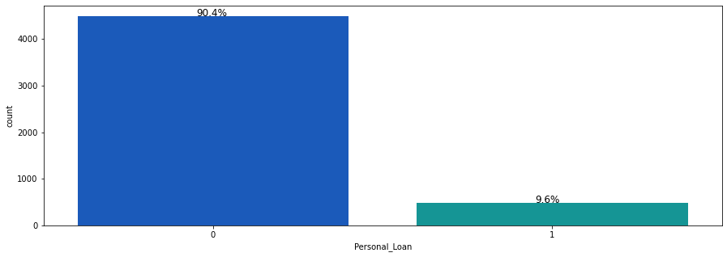

```python
plt.figure(figsize=(15,5))
ax = sns.countplot(copy_df["Personal_Loan"], palette='winter')
perc_on_bar(ax,copy_df["Personal_Loan"])
```

##### Observations

- 90.4% of customers do not have a personal loan

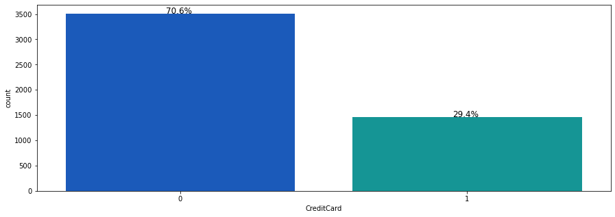

```python
plt.figure(figsize=(15,5))
ax = sns.countplot(copy_df["CreditCard"], palette='winter')
perc_on_bar(ax,copy_df["CreditCard"])
```

##### Observations

- 70.6% of customers donot have a credit card

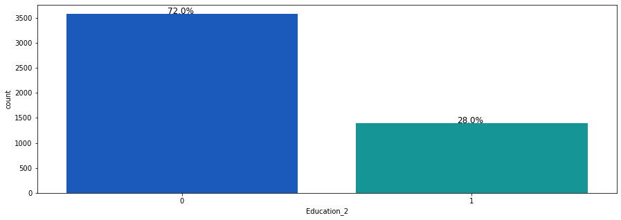

```python
plt.figure(figsize=(15,5))
ax = sns.countplot(copy_df["Education_2"], palette='winter')
perc_on_bar(ax,copy_df["Education_2"])
```

##### Observations

- 28.0% of customers have a Graduate degree

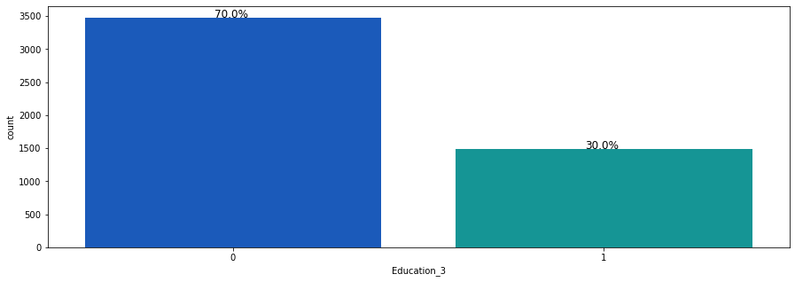

```python
plt.figure(figsize=(15,5))
ax = sns.countplot(copy_df["Education_3"], palette='winter')
perc_on_bar(ax,copy_df["Education_3"])
```

##### Observations

- 30% of customers are Advanced/Professionals

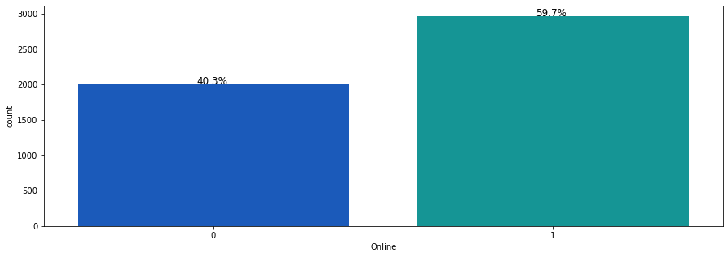

```python
plt.figure(figsize=(15,5))
ax = sns.countplot(copy_df["Online"], palette='winter')
perc_on_bar(ax,copy_df["Online"])
```

##### Observations

- 59.7% ofcustomers go online for banking services

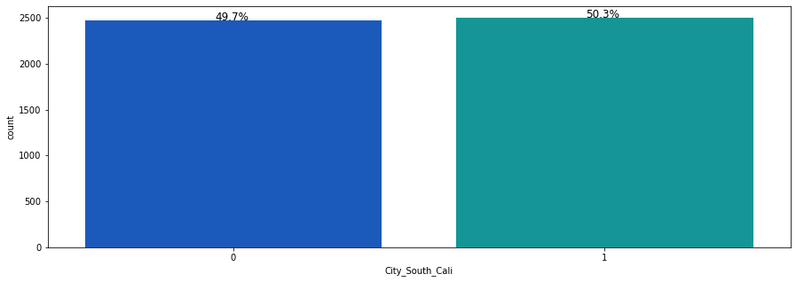

```python
plt.figure(figsize=(15,5))
ax = sns.countplot(copy_df["City_South_Cali"], palette='winter')
perc_on_bar(ax,copy_df["City_South_Cali"])
```

##### Observations

- 50.3% of customers for AllLife US Bank live in South California

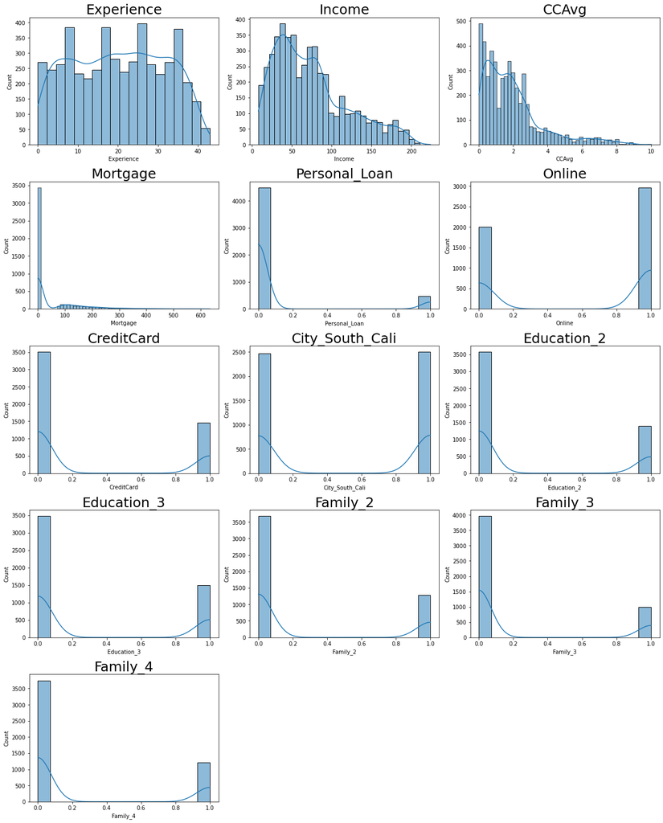

```python
all_col = copy_df.select_dtypes(include=np.number).columns.tolist()
plt.figure(figsize=(17, 75))

for i in range(len(all_col)):
    plt.subplot(18, 3, i + 1)
    sns.histplot(copy_df[all_col[i]], kde=True)
    plt.tight_layout()
    plt.title(all_col[i], fontsize=25)

plt.show()
```

## Bivariate Analysis

```python
## Function to plot stacked bar chart
def stacked_plot(x):
    sns.set(palette='nipy_spectral')
    tab1 = pd.crosstab(x,copy_df['Personal_Loan'],margins=True)
    print(tab1)
    print('-'*120)
    tab = pd.crosstab(x,copy_df['Personal_Loan'],normalize='index')
    tab.plot(kind='bar',stacked=True,figsize=(10,5))
    plt.show()
```

```
Personal_Loan     0    1   All
Online
0              1816  186  2002
1              2673  291  2964
All            4489  477  4966
------------------------------------------------------------------------------------------------------------------------
```

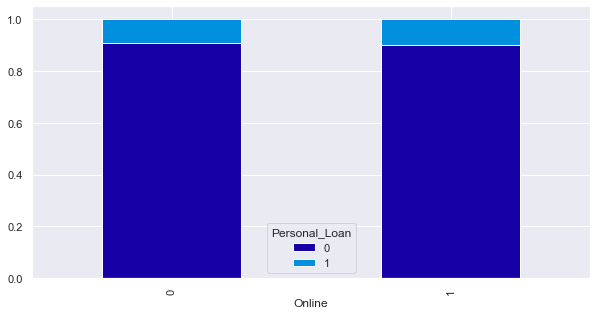

```python
stacked_plot(copy_df['Online'])
```

```
Personal_Loan     0    1   All
CreditCard
0              3173  335  3508
1              1316  142  1458
All            4489  477  4966
------------------------------------------------------------------------------------------------------------------------
```

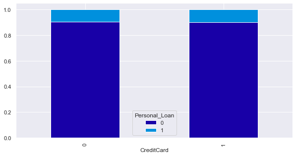

```python
stacked_plot(copy_df['CreditCard'])
```

```
Personal_Loan     0    1   All
Education_2
0              3279  297  3576
1              1210  180  1390
All            4489  477  4966
------------------------------------------------------------------------------------------------------------------------
```

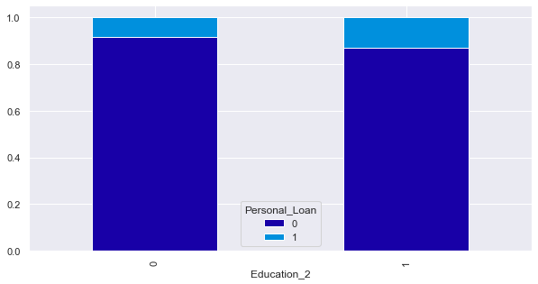

```python
stacked_plot(copy_df['Education_2'])
```

```
Personal_Loan     0    1   All
Education_3
0              3202  273  3475
1              1287  204  1491
All            4489  477  4966
------------------------------------------------------------------------------------------------------------------------
```

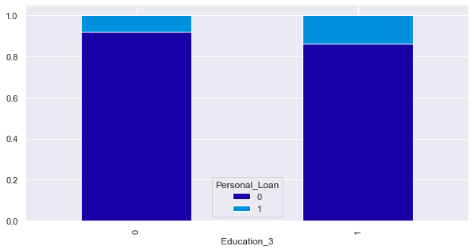

```python
stacked_plot(copy_df['Education_3'])
```

```
Personal_Loan     0    1   All
Family_2
0              3306  371  3677
1              1183  106  1289
All            4489  477  4966
------------------------------------------------------------------------------------------------------------------------
```

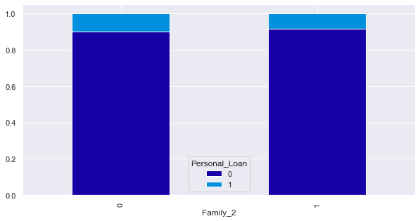

```python
stacked_plot(copy_df['Family_2'])
```

```
Personal_Loan     0    1   All
Family_3
0              3619  345  3964
1               870  132  1002
All            4489  477  4966
------------------------------------------------------------------------------------------------------------------------
```

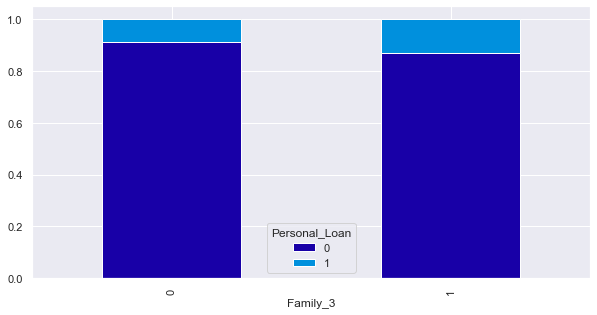

```python
stacked_plot(copy_df['Family_3'])
```

```
Personal_Loan     0    1   All
Family_4
0              3407  344  3751
1              1082  133  1215
All            4489  477  4966
------------------------------------------------------------------------------------------------------------------------
```

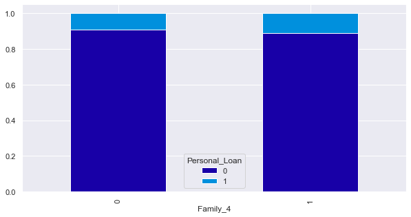

```python
stacked_plot(copy_df['Family_4'])
```

```
Personal_Loan       0    1   All
City_South_Cali
0                2230  237  2467
1                2259  240  2499
All              4489  477  4966
------------------------------------------------------------------------------------------------------------------------
```

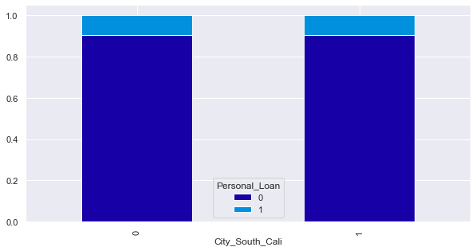

```python
stacked_plot(copy_df['City_South_Cali'])
```

```
Personal_Loan     0    1   All
Experience
0                58    7    65
1                98    8   106
2                90    9    99
3               116   17   133
4               103    9   112
5               131   14   145
6               106   12   118
7               107   12   119
8               101   17   118
9               127   20   147
10              110    7   117
11              102   13   115
12               86   15   101
```

[output cut: 33 more lines]

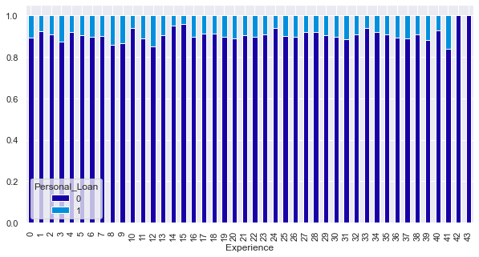

```python
stacked_plot(copy_df['Experience'])
```

##### Observations / Customers that have loans

- 291 customers that have a personal loan go online for bank services
- 142 customers that have a personal loan have a credit card
- 204 customers that have an advanced/professional education have personal loans
- 180 customers that have a graduate degree have a personal loan
- 133 customers that have more family size of 4 have personal loans. More than family sizes of 1,2,3
- 240 customers that live in South California have personal loans
- customers between 0-41 years of experience working have personal loans

###### Observations / Customers with no loans

- 2673 customers dont have a personal loan and go online for bank services
- 1316 customers dont have a personal loan but have credit cards
- 1210 customers dont have a personal loan but have a graduate degree
- 1287 customers dont have a personal loan but have advanced/professional education
- 1183 customers dont have a personal loan but have family size of 2
- 870 customers dont have a personal loan but have family size of 3
- 1082 customers dont have a personal loan but have a family size of 4
- 2259 customers dont have a personal loan but live in South California

```python
def stacked_plot_south_cali(x):
    sns.set(palette='nipy_spectral')
    tab1 = pd.crosstab(x,copy_df['City_South_Cali'],margins=True)
    print(tab1)
    print('-'*120)
    tab = pd.crosstab(x,copy_df['City_South_Cali'],normalize='index')
    tab.plot(kind='bar',stacked=True,figsize=(10,5))
    plt.legend(loc='lower left', frameon=False)
    plt.legend(loc="upper left", bbox_to_anchor=(0,1))
    plt.show()
```

```
City_South_Cali     0     1   All
Personal_Loan
0                2230  2259  4489
1                 237   240   477
All              2467  2499  4966
------------------------------------------------------------------------------------------------------------------------
```

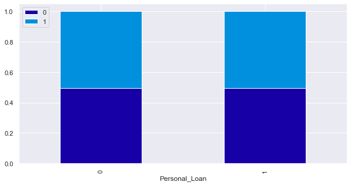

```python
stacked_plot_south_cali(copy_df['Personal_Loan'])
```

```
City_South_Cali     0     1   All
CreditCard
0                1723  1785  3508
1                 744   714  1458
All              2467  2499  4966
------------------------------------------------------------------------------------------------------------------------
```

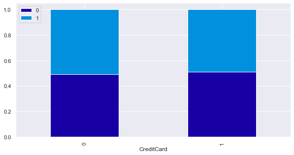

```python
stacked_plot_south_cali(copy_df['CreditCard'])
```

```
City_South_Cali     0     1   All
Education_2
0                1720  1856  3576
1                 747   643  1390
All              2467  2499  4966
------------------------------------------------------------------------------------------------------------------------
```

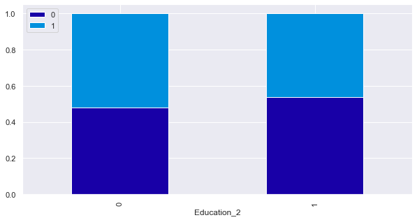

```python
stacked_plot_south_cali(copy_df['Education_2'])
```

```
City_South_Cali     0     1   All
Education_3
0                1772  1703  3475
1                 695   796  1491
All              2467  2499  4966
------------------------------------------------------------------------------------------------------------------------
```

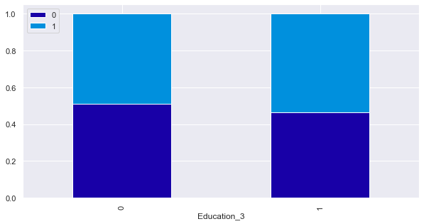

```python
stacked_plot_south_cali(copy_df['Education_3'])
```

```
City_South_Cali     0     1   All
Family_2
0                1830  1847  3677
1                 637   652  1289
All              2467  2499  4966
------------------------------------------------------------------------------------------------------------------------
```

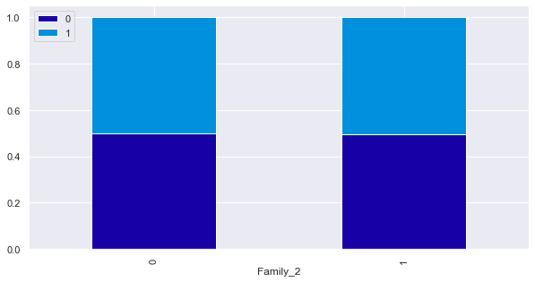

```python
stacked_plot_south_cali(copy_df['Family_2'])
```

```
City_South_Cali     0     1   All
Family_3
0                1962  2002  3964
1                 505   497  1002
All              2467  2499  4966
------------------------------------------------------------------------------------------------------------------------
```

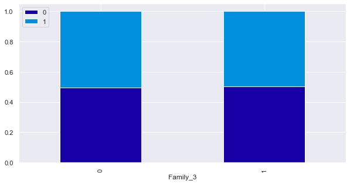

```python
stacked_plot_south_cali(copy_df['Family_3'])
```

```
City_South_Cali     0     1   All
Family_4
0                1838  1913  3751
1                 629   586  1215
All              2467  2499  4966
------------------------------------------------------------------------------------------------------------------------
```

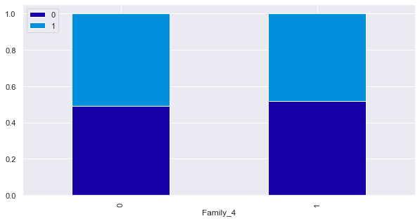

```python
stacked_plot_south_cali(copy_df['Family_4'])
```

```
City_South_Cali     0     1   All
Experience
0                  32    33    65
1                  54    52   106
2                  56    43    99
3                  68    65   133
4                  42    70   112
5                  81    64   145
6                  58    60   118
7                  66    53   119
8                  59    59   118
9                  81    66   147
10                 68    49   117
11                 63    52   115
12                 51    50   101
```

[output cut: 33 more lines]

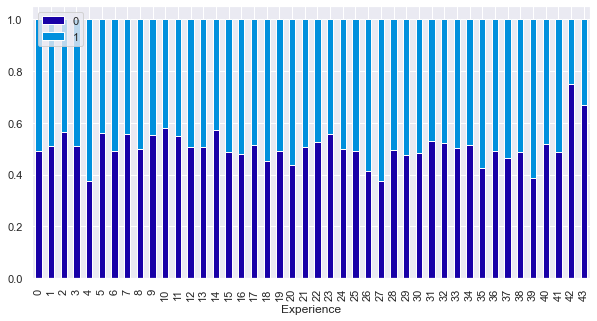

```python
stacked_plot_south_cali(copy_df['Experience'])
```

##### Observations / customers with no loans

- 2259 customers that live in south california dont have a personal loan

## Multivariate Analysis

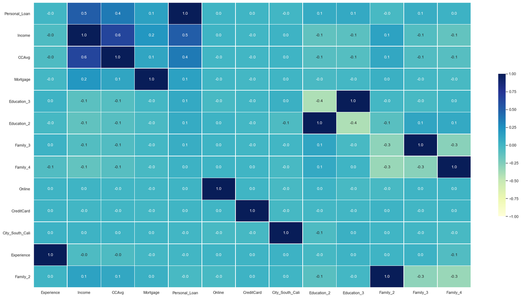

```python
# Creating heatmap for all numerical values to determin with respect to Personal Loan
numeric_columns = copy_df.select_dtypes(include=np.number).columns.tolist()
corr = (
    copy_df[numeric_columns].corr().sort_values(by=["Personal_Loan"], ascending=False)
)  # sorting correlations w.r.t Price

# Set up the matplotlib figure
f, ax = plt.subplots(figsize=(28, 15))

# Draw the heatmap with the mask and correct aspect ratio
sns.heatmap(
    corr,
    cmap="YlGnBu",
    annot=True,
    fmt=".1f",
    vmin=-1,
    vmax=1,
    center=0,
    square=False,
    linewidths=0.7,
    cbar_kws={"shrink": 0.5},
)
```

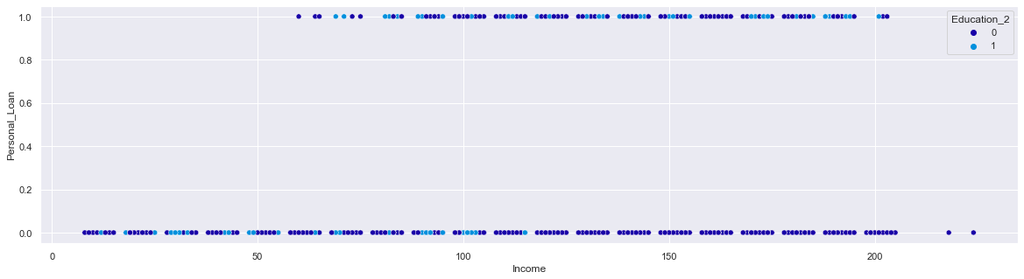

```python
plt.figure(figsize=(20, 5))
sns.scatterplot(y="Personal_Loan", x="Income", hue="Education_2", data=copy_df, ci=None);
```

The Chi-Square test is a statistical method to determine if two categorical variables have a significant correlation between them.

Null Hypothesis - There is no association between the two variables. Alternate Hypothesis - There is an association between two variables.

```python
import scipy.stats as stats
crosstab = pd.crosstab(copy_df['Personal_Loan'],copy_df['Online'])  # Contingency table of region and smoker attributes

Ho = "Online has no effect on personal loan"   # Stating the Null Hypothesis
Ha = "Online has an effect on personal loan"   # Stating the Alternate Hypothesis

chi, p_value, dof, expected =  stats.chi2_contingency(crosstab)

if p_value < 0.05:  # Setting our significance level at 5%
    print(f'{Ha} as the p_value ({p_value.round(3)}) < 0.05')
else:
    print(f'{Ho} as the p_value ({p_value.round(3)}) > 0.05')
```

```
Online has no effect on personal loan as the p_value (0.569) > 0.05
```

```python
crosstab = pd.crosstab(copy_df['Personal_Loan'],copy_df['CreditCard'])  # Contingency table of region and smoker attributes

Ho = "CreditCard has no effect on personal loan"   # Stating the Null Hypothesis
Ha = "CreditCard has an effect on personal loan"   # Stating the Alternate Hypothesis

chi, p_value, dof, expected =  stats.chi2_contingency(crosstab)

if p_value < 0.05:  # Setting our significance level at 5%
    print(f'{Ha} as the p_value ({p_value.round(3)}) < 0.05')
else:
    print(f'{Ho} as the p_value ({p_value.round(3)}) > 0.05')
```

```
CreditCard has no effect on personal loan as the p_value (0.878) > 0.05
```

```python
crosstab = pd.crosstab(copy_df['Personal_Loan'],copy_df['Education_2'])  # Contingency table of region and smoker attributes

Ho = "Education_2 has no effect on personal loan"   # Stating the Null Hypothesis
Ha = "Education_2 has an effect on personal loan"   # Stating the Alternate Hypothesis

chi, p_value, dof, expected =  stats.chi2_contingency(crosstab)

if p_value < 0.05:  # Setting our significance level at 5%
    print(f'{Ha} as the p_value ({p_value.round(3)}) < 0.05')
else:
    print(f'{Ho} as the p_value ({p_value.round(3)}) > 0.05')
```

```
Education_2 has an effect on personal loan as the p_value (0.0) < 0.05
```

```python
crosstab = pd.crosstab(copy_df['Personal_Loan'],copy_df['Education_3'])  # Contingency table of region and smoker attributes

Ho = "Education_3 has no effect on personal loan"   # Stating the Null Hypothesis
Ha = "Education_3 has an effect on personal loan"   # Stating the Alternate Hypothesis

chi, p_value, dof, expected =  stats.chi2_contingency(crosstab)

if p_value < 0.05:  # Setting our significance level at 5%
    print(f'{Ha} as the p_value ({p_value.round(3)}) < 0.05')
else:
    print(f'{Ho} as the p_value ({p_value.round(3)}) > 0.05')
```

```
Education_3 has an effect on personal loan as the p_value (0.0) < 0.05
```

```python
crosstab = pd.crosstab(copy_df['Personal_Loan'],copy_df['Family_2'])  # Contingency table of region and smoker attributes

Ho = "Family_2 has no effect on personal loan"   # Stating the Null Hypothesis
Ha = "Family_2 has an effect on personal loan"   # Stating the Alternate Hypothesis

chi, p_value, dof, expected =  stats.chi2_contingency(crosstab)

if p_value < 0.05:  # Setting our significance level at 5%
    print(f'{Ha} as the p_value ({p_value.round(3)}) < 0.05')
else:
    print(f'{Ho} as the p_value ({p_value.round(3)}) > 0.05')
```

```
Family_2 has no effect on personal loan as the p_value (0.057) > 0.05
```

```python
crosstab = pd.crosstab(copy_df['Personal_Loan'],copy_df['Family_3'])  # Contingency table of region and smoker attributes

Ho = "Family_3 has no effect on personal loan"   # Stating the Null Hypothesis
Ha = "Family_3 has an effect on personal loan"   # Stating the Alternate Hypothesis

chi, p_value, dof, expected =  stats.chi2_contingency(crosstab)

if p_value < 0.05:  # Setting our significance level at 5%
    print(f'{Ha} as the p_value ({p_value.round(3)}) < 0.05')
else:
    print(f'{Ho} as the p_value ({p_value.round(3)}) > 0.05')
```

```
Family_3 has an effect on personal loan as the p_value (0.0) < 0.05
```

```python
crosstab = pd.crosstab(copy_df['Personal_Loan'],copy_df['Family_4'])  # Contingency table of region and smoker attributes

Ho = "Family_4 has no effect on personal loan"   # Stating the Null Hypothesis
Ha = "Family_4 has an effect on personal loan"   # Stating the Alternate Hypothesis

chi, p_value, dof, expected =  stats.chi2_contingency(crosstab)

if p_value < 0.05:  # Setting our significance level at 5%
    print(f'{Ha} as the p_value ({p_value.round(3)}) < 0.05')
else:
    print(f'{Ho} as the p_value ({p_value.round(3)}) > 0.05')
```

```
Family_4 has no effect on personal loan as the p_value (0.077) > 0.05
```

```python
crosstab = pd.crosstab(copy_df['Personal_Loan'],copy_df['Income'])  # Contingency table of region and smoker attributes

Ho = "Income has no effect on personal loan"   # Stating the Null Hypothesis
Ha = "Income has an effect on personal loan"   # Stating the Alternate Hypothesis

chi, p_value, dof, expected =  stats.chi2_contingency(crosstab)

if p_value < 0.05:  # Setting our significance level at 5%
    print(f'{Ha} as the p_value ({p_value.round(3)}) < 0.05')
else:
    print(f'{Ho} as the p_value ({p_value.round(3)}) > 0.05')
```

```
Income has an effect on personal loan as the p_value (0.0) < 0.05
```

```python
crosstab = pd.crosstab(copy_df['Personal_Loan'],copy_df['Experience'])  # Contingency table of region and smoker attributes

Ho = "Experience has no effect on personal loan"   # Stating the Null Hypothesis
Ha = "Experience has an effect on personal loan"   # Stating the Alternate Hypothesis

chi, p_value, dof, expected =  stats.chi2_contingency(crosstab)

if p_value < 0.05:  # Setting our significance level at 5%
    print(f'{Ha} as the p_value ({p_value.round(3)}) < 0.05')
else:
    print(f'{Ho} as the p_value ({p_value.round(3)}) > 0.05')
```

```
Experience has no effect on personal loan as the p_value (0.893) > 0.05
```

```python
crosstab = pd.crosstab(copy_df['Personal_Loan'],copy_df['CCAvg'])  # Contingency table of region and smoker attributes

Ho = "CCAvg has no effect on personal loan"   # Stating the Null Hypothesis
Ha = "CCAvg has an effect on personal loan"   # Stating the Alternate Hypothesis

chi, p_value, dof, expected =  stats.chi2_contingency(crosstab)

if p_value < 0.05:  # Setting our significance level at 5%
    print(f'{Ha} as the p_value ({p_value.round(3)}) < 0.05')
else:
    print(f'{Ho} as the p_value ({p_value.round(3)}) > 0.05')
```

```
CCAvg has an effect on personal loan as the p_value (0.0) < 0.05
```

```python
crosstab = pd.crosstab(copy_df['Personal_Loan'],copy_df['City_South_Cali'])  # Contingency table of region and smoker attributes

Ho = "City_South_Cali has no effect on personal loan"   # Stating the Null Hypothesis
Ha = "City_South_Cali has an effect on personal loan"   # Stating the Alternate Hypothesis

chi, p_value, dof, expected =  stats.chi2_contingency(crosstab)

if p_value < 0.05:  # Setting our significance level at 5%
    print(f'{Ha} as the p_value ({p_value.round(3)}) < 0.05')
else:
    print(f'{Ho} as the p_value ({p_value.round(3)}) > 0.05')
```

```
City_South_Cali has no effect on personal loan as the p_value (0.964) > 0.05
```

##### Observations / have effect on personal loans

- Education_2 (graduate degree) has an effect on personal loans
- Education_3 (advanced/professional) has an effect on peronsl loans
- Family_3 has an effect on personal loans
- Income has an effect on personal loans
- Credit Card Spending Average has an effect on personal loans

##### Observations / have no effect on personal loans

- Online services have no effect on personal loans
- Credit Card have has no effect on peronsl loans
- Family_2 has no effects on peronsl loans
- Experience has no effect on personal loans
- City_South_Cali has no effect on personal loans

## Split Data

```python
x = copy_df.drop(["Personal_Loan"], axis=1)
y = copy_df["Personal_Loan"]
```

```python
# encoding the categorical variables
x = pd.get_dummies(x, drop_first=True)
x.head()
```

|  | Experience | Income | CCAvg | Mortgage | Online | CreditCard | City_South_Cali | Education_2 | Education_3 | Family_2 | Family_3 | Family_4 |
| --- | --- | --- | --- | --- | --- | --- | --- | --- | --- | --- | --- | --- |
| 0 | 1 | 49 | 1.6 | 0 | 0 | 0 | 1 | 0 | 0 | 0 | 0 | 1 |
| 1 | 19 | 34 | 1.5 | 0 | 0 | 0 | 1 | 0 | 0 | 0 | 1 | 0 |
| 2 | 15 | 11 | 1.0 | 0 | 0 | 0 | 0 | 0 | 0 | 0 | 0 | 0 |
| 3 | 9 | 100 | 2.7 | 0 | 0 | 0 | 0 | 1 | 0 | 0 | 0 | 0 |
| 4 | 8 | 45 | 1.0 | 0 | 0 | 1 | 1 | 1 | 0 | 0 | 0 | 1 |

```python
xtrain, xtest, ytrain, ytest = train_test_split(x, y, test_size=0.4 , random_state=1)
```

```python
print(xtrain.shape)
print(xtest.shape)
print(ytrain.shape)
print(ytest.shape)
```

```
(2979, 12)
(1987, 12)
(2979,)
(1987,)
```

```python
copy_df[copy_df.columns[:]].corr()["Personal_Loan"][:]
```

```
Experience        -0.007554
Income             0.503186
CCAvg              0.366488
Mortgage           0.140844
Personal_Loan      1.000000
Online             0.008775
CreditCard         0.002933
City_South_Cali   -0.000050
Education_2        0.070760
Education_3        0.090626
Family_2          -0.027767
Family_3           0.060884
Family_4           0.025905
Name: Personal_Loan, dtype: float64
```

## Decision Tree Model

```python
y.value_counts()
```

```
0    4489
1     477
Name: Personal_Loan, dtype: int64
```

```python
model = DecisionTreeClassifier(criterion = 'gini', random_state=1)
model.fit(xtrain, ytrain)
```

```
DecisionTreeClassifier(random_state=1)
```

## Scoring Desicion Tree Model

```python
# accuracy on training set
print("Accuracy on train set", model.score(xtrain,ytrain))

# accuracy on test set
print("Accuracy on test set", model.score(xtest,ytest))
```

```
Accuracy on train set 1.0
Accuracy on test set 0.980372420734776
```

##### Observations

- Model is 98% accurate

### Confusion Matrix

```python
## Function to create confusion matrix
def make_confusion_matrix(model,y_actual,labels=[0, 1]):
    '''
    model : classifier to predict values of X
    y_actual : ground truth

    '''
    y_predict = model.predict(xtest)
    cm=metrics.confusion_matrix( y_actual, y_predict, labels=[0, 1])
    df_cm = pd.DataFrame(cm, index = [i for i in ["Actual - No","Actual - Yes"]],
                  columns = [i for i in ['Predicted - No','Predicted - Yes']])
    group_counts = ["{0:0.0f}".format(value) for value in
                cm.flatten()]
    group_percentages = ["{0:.2%}".format(value) for value in
                         cm.flatten()/np.sum(cm)]
    labels = [f"{v1}\n{v2}" for v1, v2 in
              zip(group_counts,group_percentages)]
    labels = np.asarray(labels).reshape(2,2)
    plt.figure(figsize = (10,7))
    sns.heatmap(df_cm, annot=labels,fmt='')
    plt.ylabel('True label')
    plt.xlabel('Predicted label')
```

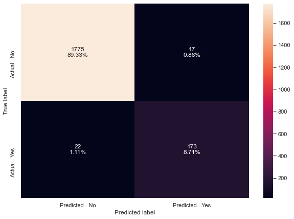

```python
make_confusion_matrix(model,ytest)
```

```python
##  Function to calculate recall score
def get_recall_score(model):
    '''
    model : classifier to predict values of X

    '''
    pred_train = model.predict(xtrain)
    pred_test = model.predict(xtest)
    print("Recall on training set : ",metrics.recall_score(ytrain,pred_train))
    print("Recall on test set : ",metrics.recall_score(ytest,pred_test))
```

```python
get_recall_score(model)
```

```
Recall on training set :  1.0
Recall on test set :  0.8871794871794871
```

##### Observations

- Recall on train and test set are very good

### Visualizing Decision Tree

```python
column_names = list(x.columns)
feature_names = column_names
print(feature_names)
```

```
['Experience', 'Income', 'CCAvg', 'Mortgage', 'Online', 'CreditCard', 'City_South_Cali', 'Education_2', 'Education_3', 'Family_2', 'Family_3', 'Family_4']
```

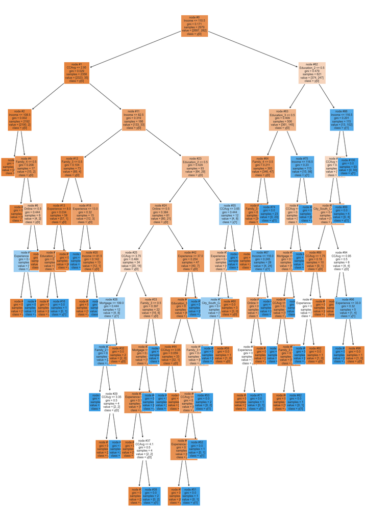

```python
plt.figure(figsize=(20,30))

out = tree.plot_tree(model,feature_names=feature_names,filled=True,fontsize=9,node_ids=True,class_names=True)
for o in out:
     arrow = o.arrow_patch
     if arrow is not None:
        arrow.set_edgecolor('black')
        arrow.set_linewidth(1)
plt.show()
```

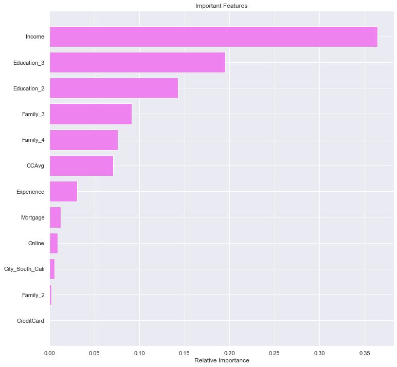

```python
importances = model.feature_importances_
indices = np.argsort(importances)

plt.figure(figsize=(12,12))
plt.title('Important Features')
plt.barh(range(len(indices)), importances[indices], color='violet', align='center')
plt.yticks(range(len(indices)), [feature_names[i] for i in indices])
plt.xlabel('Relative Importance')
plt.show()
```

##### Observations

- Income, Education_3 (Advanced/Professional), Education_2 (Graduate Degree), are the top 3 most important features

```python
# Choose the type of classifier.
estimator = DecisionTreeClassifier(random_state=1)

# Grid of parameters to choose from
parameters = {'max_depth': np.arange(1,10),
              'min_samples_leaf': [1, 2, 5, 7, 10,15,20],
              'max_leaf_nodes' : [5, 10,15,20,25,30],
              'min_impurity_decrease': [0.0001,0.001,0.01,0.1]
             }

# Type of scoring used to compare parameter combinations
acc_scorer = metrics.make_scorer(metrics.recall_score)

# Run the grid search
grid_obj = GridSearchCV(estimator, parameters, scoring=acc_scorer,cv=5)
grid_obj = grid_obj.fit(xtrain, ytrain)

# Set the clf to the best combination of parameters
estimator = grid_obj.best_estimator_

# Fit the best algorithm to the data.
estimator.fit(xtrain, ytrain)
```

```
DecisionTreeClassifier(max_depth=9, max_leaf_nodes=30,
                       min_impurity_decrease=0.0001, random_state=1)
```

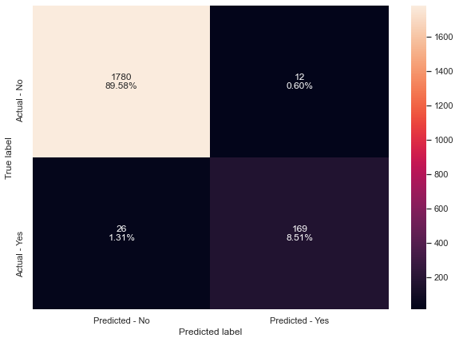

```python
make_confusion_matrix(estimator,ytest)
```

```python
get_recall_score(estimator)
```

```
Recall on training set :  0.9468085106382979
Recall on test set :  0.8666666666666667
```

```python
column_names = list(x.columns)
feature_names = column_names
print(feature_names)
```

```
['Experience', 'Income', 'CCAvg', 'Mortgage', 'Online', 'CreditCard', 'City_South_Cali', 'Education_2', 'Education_3', 'Family_2', 'Family_3', 'Family_4']
```

[figure not shown]

```python
plt.figure(figsize=(5,5))

tree.plot_tree(estimator,feature_names=feature_names,filled=True,fontsize=9,node_ids=True,class_names=True)
plt.show()
```